# R Notebook

```r
library(tidyverse)
library(skimr)
library(leaps)
library(ggfortify)
library(GGally)
library(modelr)
library(caret)
```

```r
avocado <- read_csv("data/avocado.csv") %>%
  janitor::clean_names()
avocado %>%
  skim()
```

```
── Data Summary ────────────────────────
                           Values
Name                       Piped data
Number of rows             18249
Number of columns          14
_______________________
Column type frequency:
  character                2
  Date                     1
  numeric                  11
________________________
Group variables            None
```

|  | skim_variable | n_missing | complete_rate | min | max | empty | n_unique | whitespace |
| --- | --- | --- | --- | --- | --- | --- | --- | --- |
| 1 | type | 0 | 1 | 7 | 12 | 0 | 2 | 0 |
| 2 | region | 0 | 1 | 4 | 19 | 0 | 54 | 0 |

|  | skim_variable | n_missing | complete_rate | min | max | median | n_unique |
| --- | --- | --- | --- | --- | --- | --- | --- |
| 1 | date | 0 | 1 | 2015-01-04 | 2018-03-25 | 2016-08-14 | 169 |

|  | skim_variable | n_missing | complete_rate | mean | sd | p0 | p25 | p50 | p75 | p100 | hist |
| --- | --- | --- | --- | --- | --- | --- | --- | --- | --- | --- | --- |
| 1 | x1 | 0 | 1 | 2.423223e+01 | 1.548104e+01 | 0.00 | 10.00 | 24.00 | 38.00 | 52.00 | ▇▆▆▆▆ |
| 2 | average_price | 0 | 1 | 1.405978e+00 | 4.026766e-01 | 0.44 | 1.10 | 1.37 | 1.66 | 3.25 | ▂▇▅▁▁ |
| 3 | total_volume | 0 | 1 | 8.506440e+05 | 3.453545e+06 | 84.56 | 10838.58 | 107376.76 | 432962.29 | 62505646.52 | ▇▁▁▁▁ |
| 4 | x4046 | 0 | 1 | 2.930084e+05 | 1.264989e+06 | 0.00 | 854.07 | 8645.30 | 111020.20 | 22743616.17 | ▇▁▁▁▁ |
| 5 | x4225 | 0 | 1 | 2.951546e+05 | 1.204120e+06 | 0.00 | 3008.78 | 29061.02 | 150206.86 | 20470572.61 | ▇▁▁▁▁ |
| 6 | x4770 | 0 | 1 | 2.283974e+04 | 1.074641e+05 | 0.00 | 0.00 | 184.99 | 6243.42 | 2546439.11 | ▇▁▁▁▁ |
| 7 | total_bags | 0 | 1 | 2.396392e+05 | 9.862424e+05 | 0.00 | 5088.64 | 39743.83 | 110783.37 | 19373134.37 | ▇▁▁▁▁ |
| 8 | small_bags | 0 | 1 | 1.821947e+05 | 7.461785e+05 | 0.00 | 2849.42 | 26362.82 | 83337.67 | 13384586.80 | ▇▁▁▁▁ |
| 9 | large_bags | 0 | 1 | 5.433809e+04 | 2.439660e+05 | 0.00 | 127.47 | 2647.71 | 22029.25 | 5719096.61 | ▇▁▁▁▁ |
| 10 | x_large_bags | 0 | 1 | 3.106427e+03 | 1.769289e+04 | 0.00 | 0.00 | 0.00 | 132.50 | 551693.65 | ▇▁▁▁▁ |

[output cut: 1 more lines]

# clean and modify data

Several transformations were made to the dataset which could help explain why the average price of an avocado would fluctuate, this meant that proportions and logarithmic transformations were preferred for this analysis, some of this cleaning was made retrospectively as the model was being developed to assist with explaining how the predicted variable changed with the predictors.

```r
avocado_clean <- avocado %>%
  filter(total_bags > 0) %>%
  select(-1, - date) %>%
  mutate(prop_4046 = x4046 / total_volume,
         prop_4225 = x4225 / total_volume,
         prop_4770 = x4770 / total_volume,
         prop_small_bags = small_bags / total_bags,
         prop_large_bags = large_bags / total_bags,
         prop_x_large_bags = x_large_bags / total_bags,
         ln_total_volume = log(total_volume),
         year = factor(year)) %>%
  select(-c(total_volume:x_large_bags, prop_4770, prop_x_large_bags))

skim(avocado_clean)
```

```
── Data Summary ────────────────────────
                           Values
Name                       avocado_clean
Number of rows             18234
Number of columns          9
_______________________
Column type frequency:
  character                2
  factor                   1
  numeric                  6
________________________
Group variables            None
```

|  | skim_variable | n_missing | complete_rate | min | max | empty | n_unique | whitespace |
| --- | --- | --- | --- | --- | --- | --- | --- | --- |
| 1 | type | 0 | 1 | 7 | 12 | 0 | 2 | 0 |
| 2 | region | 0 | 1 | 4 | 19 | 0 | 54 | 0 |

|  | skim_variable | n_missing | complete_rate | ordered | n_unique | top_counts |
| --- | --- | --- | --- | --- | --- | --- |
| 1 | year | 0 | 1 | FALSE | 4 | 201: 5722, 201: 5616, 201: 5600, 201: 1296 |

|  | skim_variable | n_missing | complete_rate | mean | sd | p0 | p25 | p50 | p75 | p100 | hist |
| --- | --- | --- | --- | --- | --- | --- | --- | --- | --- | --- | --- |
| 1 | average_price | 0 | 1 | 1.4055715 | 0.4024226 | 0.440000 | 1.100000000 | 1.3700000 | 1.6600000 | 3.2500000 | ▂▇▅▁▁ |
| 2 | prop_4046 | 0 | 1 | 0.2251370 | 0.2139434 | 0.000000 | 0.032704584 | 0.1577337 | 0.3787382 | 0.9725234 | ▇▃▂▁▁ |
| 3 | prop_4225 | 0 | 1 | 0.3470886 | 0.2347179 | 0.000000 | 0.157098288 | 0.3165176 | 0.5169322 | 0.9926278 | ▇▇▆▃▁ |
| 4 | prop_small_bags | 0 | 1 | 0.7499352 | 0.2849803 | 0.000000 | 0.583634350 | 0.8717554 | 0.9872986 | 1.0000000 | ▁▁▂▂▇ |
| 5 | prop_large_bags | 0 | 1 | 0.2425199 | 0.2854175 | 0.000000 | 0.009446003 | 0.1163381 | 0.4052176 | 1.0000000 | ▇▂▂▁▁ |
| 6 | ln_total_volume | 0 | 1 | 11.3179988 | 2.2935274 | 4.437461 | 9.291954448 | 11.5876150 | 12.9797786 | 17.9507675 | ▁▇▇▆▁ |

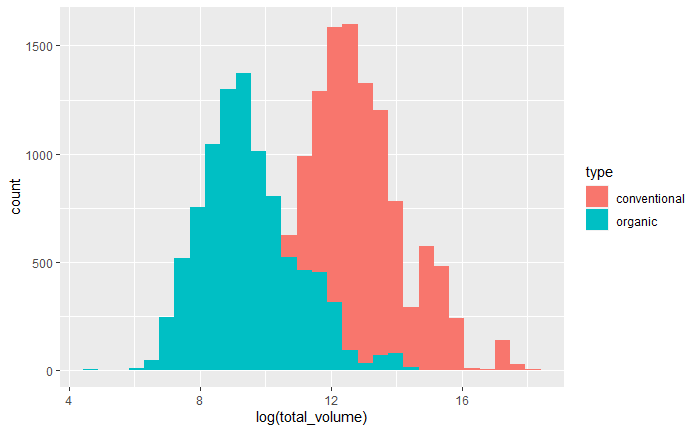

```r
avocado %>%
  ggplot(aes(log(total_volume), fill = type)) +
  geom_histogram()
```

```r
avocado_clean %>%
  ggpairs(aes(colour = type, alpha = 0.5), progress = FALSE)
```

```
Error in stop_if_high_cardinality(data, columns, cardinality_threshold) :
  Column 'region' has more levels (54) than the threshold (15) allowed.
Please remove the column or increase the 'cardinality_threshold' parameter. Increasing the cardinality_threshold may produce long processing times
```

# Create test/train split

```r
n_data <- nrow(avocado_clean)

test_index <- sample(1:n_data, size = n_data * 0.2)

test <- slice(avocado_clean, test_index)
train <- slice(avocado_clean, -test_index)
```

# automatic model selection

```r
regsubsets_forward <- regsubsets(average_price ~ .,
                                 data = avocado_clean,
                                 nvmax = 15,
                                 method = "forward")

sum_regsubsets_forward <- summary(regsubsets_forward)

sum_regsubsets_forward
```

```
Subset selection object
Call: regsubsets.formula(average_price ~ ., data = avocado_clean, nvmax = 15,
    method = "forward")
9 Variables  (and intercept)
                Forced in Forced out
typeorganic         FALSE      FALSE
year2016            FALSE      FALSE
year2017            FALSE      FALSE
year2018            FALSE      FALSE
prop_4046           FALSE      FALSE
prop_4225           FALSE      FALSE
prop_small_bags     FALSE      FALSE
prop_large_bags     FALSE      FALSE
ln_total_volume     FALSE      FALSE
1 subsets of each size up to 9
Selection Algorithm: forward
         typeorganic year2016 year2017 year2018 prop_4046 prop_4225 prop_small_bags prop_large_bags ln_total_volume
1  ( 1 ) "*"         " "      " "      " "      " "       " "       " "             " "             " "
2  ( 1 ) "*"         " "      " "      " "      " "       "*"       " "             " "             " "
3  ( 1 ) "*"         " "      "*"      " "      " "       "*"       " "             " "             " "
4  ( 1 ) "*"         " "      "*"      " "      " "       "*"       " "             "*"             " "
5  ( 1 ) "*"         " "      "*"      " "      " "       "*"       " "             "*"             "*"
6  ( 1 ) "*"         " "      "*"      " "      "*"       "*"       " "             "*"             "*"
7  ( 1 ) "*"         " "      "*"      "*"      "*"       "*"       " "             "*"             "*"
8  ( 1 ) "*"         "*"      "*"      "*"      "*"       "*"       " "             "*"             "*"
9  ( 1 ) "*"         "*"      "*"      "*"      "*"       "*"       "*"             "*"             "*"
```

```r
sum_regsubsets_forward$rsq
```

```
[1] 0.3791216 0.4279835 0.4748075 0.5163137 0.5429615 0.5455814 0.5481360 0.5493780 0.5499022
```

```r
sum_regsubsets_forward$adjr2
```

```
[1] 0.3790875 0.4279207 0.4747210 0.5162075 0.5428361 0.5454318 0.5479624 0.5491802 0.5496799
```

```r
sum_regsubsets_forward$which
```

```
  (Intercept) typeorganic year2016 year2017 year2018 prop_4046 prop_4225 prop_small_bags prop_large_bags ln_total_volume
1        TRUE        TRUE    FALSE    FALSE    FALSE     FALSE     FALSE           FALSE           FALSE           FALSE
2        TRUE        TRUE    FALSE    FALSE    FALSE     FALSE      TRUE           FALSE           FALSE           FALSE
3        TRUE        TRUE    FALSE     TRUE    FALSE     FALSE      TRUE           FALSE           FALSE           FALSE
4        TRUE        TRUE    FALSE     TRUE    FALSE     FALSE      TRUE           FALSE            TRUE           FALSE
5        TRUE        TRUE    FALSE     TRUE    FALSE     FALSE      TRUE           FALSE            TRUE            TRUE
6        TRUE        TRUE    FALSE     TRUE    FALSE      TRUE      TRUE           FALSE            TRUE            TRUE
7        TRUE        TRUE    FALSE     TRUE     TRUE      TRUE      TRUE           FALSE            TRUE            TRUE
8        TRUE        TRUE     TRUE     TRUE     TRUE      TRUE      TRUE           FALSE            TRUE            TRUE
9        TRUE        TRUE     TRUE     TRUE     TRUE      TRUE      TRUE            TRUE            TRUE            TRUE
```

```r
plot(regsubsets_forward, scale = "adjr2")
```

```r
plot(regsubsets_forward, scale = "bic")
```

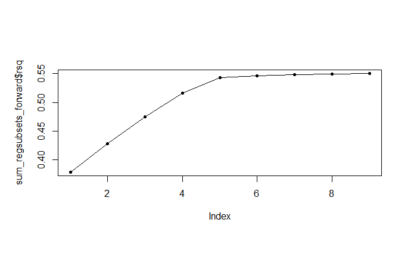

```r
plot(sum_regsubsets_forward$rsq, type = "o", pch = 20)
```

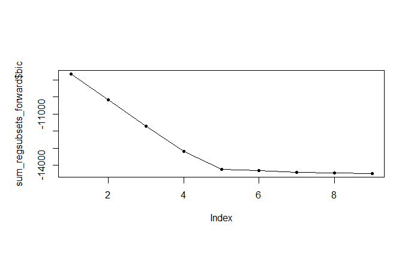

```r
plot(sum_regsubsets_forward$bic, type = "o", pch = 20)
```

```r
regsubsets_backward <- regsubsets(average_price ~ .,
                                 data = avocado_clean,
                                 nvmax = 15,
                                 method = "backward")

sum_regsubsets_backward <- summary(regsubsets_backward)

sum_regsubsets_backward
```

```
Subset selection object
Call: regsubsets.formula(average_price ~ ., data = avocado_clean, nvmax = 15,
    method = "backward")
9 Variables  (and intercept)
                Forced in Forced out
typeorganic         FALSE      FALSE
year2016            FALSE      FALSE
year2017            FALSE      FALSE
year2018            FALSE      FALSE
prop_4046           FALSE      FALSE
prop_4225           FALSE      FALSE
prop_small_bags     FALSE      FALSE
prop_large_bags     FALSE      FALSE
ln_total_volume     FALSE      FALSE
1 subsets of each size up to 9
Selection Algorithm: backward
         typeorganic year2016 year2017 year2018 prop_4046 prop_4225 prop_small_bags prop_large_bags ln_total_volume
1  ( 1 ) "*"         " "      " "      " "      " "       " "       " "             " "             " "
2  ( 1 ) "*"         " "      " "      " "      " "       "*"       " "             " "             " "
3  ( 1 ) "*"         " "      "*"      " "      " "       "*"       " "             " "             " "
4  ( 1 ) "*"         " "      "*"      " "      " "       "*"       " "             "*"             " "
5  ( 1 ) "*"         " "      "*"      " "      " "       "*"       " "             "*"             "*"
6  ( 1 ) "*"         " "      "*"      " "      "*"       "*"       " "             "*"             "*"
7  ( 1 ) "*"         " "      "*"      "*"      "*"       "*"       " "             "*"             "*"
8  ( 1 ) "*"         "*"      "*"      "*"      "*"       "*"       " "             "*"             "*"
9  ( 1 ) "*"         "*"      "*"      "*"      "*"       "*"       "*"             "*"             "*"
```

```r
regsubsets_exhaustive <- regsubsets(average_price ~ .,
                                 data = avocado_clean,
                                 nvmax = 15,
                                 method = "exhaustive")

sum_regsubsets_exhaustive <- summary(regsubsets_exhaustive)

sum_regsubsets_exhaustive
```

```
Subset selection object
Call: regsubsets.formula(average_price ~ ., data = avocado_clean, nvmax = 15,
    method = "exhaustive")
9 Variables  (and intercept)
                Forced in Forced out
typeorganic         FALSE      FALSE
year2016            FALSE      FALSE
year2017            FALSE      FALSE
year2018            FALSE      FALSE
prop_4046           FALSE      FALSE
prop_4225           FALSE      FALSE
prop_small_bags     FALSE      FALSE
prop_large_bags     FALSE      FALSE
ln_total_volume     FALSE      FALSE
1 subsets of each size up to 9
Selection Algorithm: exhaustive
         typeorganic year2016 year2017 year2018 prop_4046 prop_4225 prop_small_bags prop_large_bags ln_total_volume
1  ( 1 ) "*"         " "      " "      " "      " "       " "       " "             " "             " "
2  ( 1 ) "*"         " "      " "      " "      " "       "*"       " "             " "             " "
3  ( 1 ) "*"         " "      "*"      " "      " "       "*"       " "             " "             " "
4  ( 1 ) "*"         " "      "*"      " "      " "       "*"       " "             "*"             " "
5  ( 1 ) "*"         " "      "*"      " "      " "       "*"       " "             "*"             "*"
6  ( 1 ) "*"         " "      "*"      " "      "*"       "*"       " "             "*"             "*"
7  ( 1 ) "*"         " "      "*"      "*"      "*"       "*"       " "             "*"             "*"
8  ( 1 ) "*"         "*"      "*"      "*"      "*"       "*"       " "             "*"             "*"
9  ( 1 ) "*"         "*"      "*"      "*"      "*"       "*"       "*"             "*"             "*"
```

```r
sum_regsubsets_exhaustive$rsq
```

```
[1] 0.3791216 0.4279835 0.4748075 0.5163137 0.5429615 0.5455814 0.5481360 0.5493780 0.5499022
```

```r
sum_regsubsets_exhaustive$adjr2
```

```
[1] 0.3790875 0.4279207 0.4747210 0.5162075 0.5428361 0.5454318 0.5479624 0.5491802 0.5496799
```

```r
plot(regsubsets_backward, scale = "bic")
```

```r
plot(regsubsets_exhaustive, scale = "bic")
```

```r
plot(regsubsets_backward, scale = "adjr2")
```

```r
plot(regsubsets_exhaustive, scale = "adjr2")
```

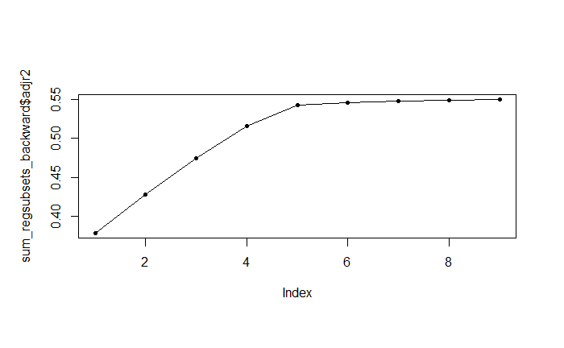

```r
plot(sum_regsubsets_backward$adjr2, type = "o", pch = 20)
```

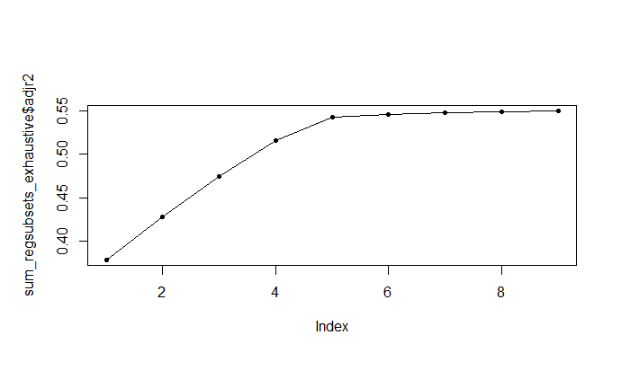

```r
plot(sum_regsubsets_exhaustive$adjr2, type = "o", pch = 20)
```

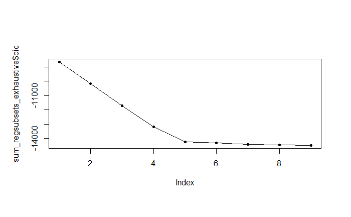

```r
plot(sum_regsubsets_exhaustive$bic, type = "o", pch = 20)
```

# Selected model

The best fitting model was obtained using the automatic model selection features of the leaps package. The original model selected did not include all predictors included in the final model.

```r
model <- lm(average_price ~ type + prop_4225 + year + prop_large_bags +
              ln_total_volume + prop_4046,
            avocado_clean)

summary(model)
```

```
Call:
lm(formula = average_price ~ type + prop_4225 + year + prop_large_bags +
    ln_total_volume + prop_4046, data = avocado_clean)

Residuals:
     Min       1Q   Median       3Q      Max
-0.93678 -0.17594 -0.01077  0.15823  1.39978

Coefficients:
                 Estimate Std. Error t value Pr(>|t|)
(Intercept)      1.561073   0.019824  78.748  < 2e-16 ***
typeorganic      0.376356   0.006807  55.293  < 2e-16 ***
prop_4225        0.550825   0.010917  50.456  < 2e-16 ***
year2016         0.037988   0.005360   7.088 1.41e-12 ***
year2017         0.249149   0.005564  44.775  < 2e-16 ***
year2018         0.106147   0.008797  12.067  < 2e-16 ***
prop_large_bags -0.286467   0.007115 -40.265  < 2e-16 ***
ln_total_volume -0.053145   0.001490 -35.672  < 2e-16 ***
prop_4046        0.172609   0.012828  13.456  < 2e-16 ***
---
Signif. codes:  0 ‘***’ 0.001 ‘**’ 0.01 ‘*’ 0.05 ‘.’ 0.1 ‘ ’ 1

Residual standard error: 0.2702 on 18225 degrees of freedom
Multiple R-squared:  0.5494,    Adjusted R-squared:  0.5492
F-statistic:  2777 on 8 and 18225 DF,  p-value: < 2.2e-16
```

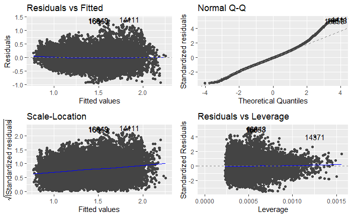

```r
autoplot(model)
```

The model residuals show consistent randomness in scale and direction from plot one of the above, it also shows moderate normality with a light right_skew. From the scale-location plot the standardised residuals appear to show a very small upwards trend as fitted values increase, for the purposes of the model the graphs achieve the desired plots relatively well and will therefore be assumed to be appropriate for estimating average avocado prices.

```r
test %>%
  add_residuals(model) %>%
  mutate(squared_error = resid^2) %>%
  summarise(mse = mean(squared_error))
```

| mse |
| --- |
| 0.07623658 |

```r
NA
```

MSE seems rather high compared with the size of the “average price” variable. Time to check if other predictors can be incorporated.

Check to see if region has any affect on the performance of the model.

```r
model_with_region <- lm(average_price ~ type + prop_4225 + year + prop_large_bags +
              ln_total_volume + prop_4046 + region,
             avocado_clean)

anova(model, model_with_region)
```

```
Analysis of Variance Table

Model 1: average_price ~ type + prop_4225 + year + prop_large_bags + ln_total_volume +
    prop_4046
Model 2: average_price ~ type + prop_4225 + year + prop_large_bags + ln_total_volume +
    prop_4046 + region
  Res.Df     RSS Df Sum of Sq      F    Pr(>F)
1  18225 1330.56
2  18172  871.02 53    459.54 180.89 < 2.2e-16 ***
---
Signif. codes:  0 ‘***’ 0.001 ‘**’ 0.01 ‘*’ 0.05 ‘.’ 0.1 ‘ ’ 1
```

```r
summary(model_with_region)
```

```
Call:
lm(formula = average_price ~ type + prop_4225 + year + prop_large_bags +
    ln_total_volume + prop_4046 + region, data = avocado_clean)

Residuals:
     Min       1Q   Median       3Q      Max
-1.08017 -0.13602 -0.00544  0.11696  1.19596

Coefficients:
                           Estimate Std. Error t value Pr(>|t|)
(Intercept)                4.111065   0.047052  87.373  < 2e-16 ***
typeorganic               -0.457570   0.015433 -29.649  < 2e-16 ***
prop_4225                  0.426345   0.010924  39.027  < 2e-16 ***
year2016                   0.095773   0.004509  21.241  < 2e-16 ***
year2017                   0.336374   0.004830  69.636  < 2e-16 ***
year2018                   0.254660   0.007595  33.530  < 2e-16 ***
prop_large_bags           -0.064779   0.007768  -8.339  < 2e-16 ***
ln_total_volume           -0.282391   0.004014 -70.347  < 2e-16 ***
prop_4046                  0.346972   0.013873  25.011  < 2e-16 ***
regionAtlanta              0.244365   0.018658  13.097  < 2e-16 ***
regionBaltimoreWashington  0.564458   0.019200  29.399  < 2e-16 ***
regionBoise               -0.179356   0.017333 -10.348  < 2e-16 ***
regionBoston               0.478720   0.018291  26.173  < 2e-16 ***
regionBuffaloRochester     0.201805   0.017097  11.803  < 2e-16 ***
regionCalifornia           0.964446   0.024236  39.793  < 2e-16 ***
regionCharlotte            0.316913   0.017344  18.272  < 2e-16 ***
regionChicago              0.545683   0.019932  27.377  < 2e-16 ***
regionCincinnatiDayton     0.087674   0.018045   4.859 1.19e-06 ***
regionColumbus            -0.038116   0.017505  -2.177 0.029460 *
regionDallasFtWorth        0.198140   0.020131   9.842  < 2e-16 ***
regionDenver               0.389222   0.019559  19.900  < 2e-16 ***
regionDetroit              0.210085   0.018121  11.593  < 2e-16 ***
regionGrandRapids          0.024755   0.016966   1.459 0.144568
regionGreatLakes           0.848715   0.022637  37.493  < 2e-16 ***
regionHarrisburgScranton   0.315683   0.017469  18.071  < 2e-16 ***
regionHartfordSpringfield  0.530962   0.017803  29.825  < 2e-16 ***
regionHouston              0.168192   0.020127   8.357  < 2e-16 ***
regionIndianapolis        -0.032838   0.017167  -1.913 0.055784 .
regionJacksonville         0.109528   0.017982   6.091 1.15e-09 ***
regionLasVegas             0.178873   0.018006   9.934  < 2e-16 ***
```

[output cut: 23 more lines]

```
regionSouthCentral         0.681232   0.023722  28.717  < 2e-16 ***
regionSoutheast            0.835615   0.021989  38.001  < 2e-16 ***
regionSpokane             -0.056673   0.017299  -3.276 0.001054 **
regionStLouis              0.151505   0.017738   8.541  < 2e-16 ***
regionSyracuse            -0.015503   0.016945  -0.915 0.360275
regionTampa                0.187368   0.017917  10.458  < 2e-16 ***
regionTotalUS              1.448321   0.029284  49.458  < 2e-16 ***
regionWest                 0.977341   0.024247  40.308  < 2e-16 ***
regionWestTexNewMexico     0.274789   0.019183  14.325  < 2e-16 ***
---
Signif. codes:  0 ‘***’ 0.001 ‘**’ 0.01 ‘*’ 0.05 ‘.’ 0.1 ‘ ’ 1

Residual standard error: 0.2189 on 18172 degrees of freedom
Multiple R-squared:  0.705, Adjusted R-squared:  0.704
F-statistic:   712 on 61 and 18172 DF,  p-value: < 2.2e-16
```

The inclusion of the region is statistically significant, based on the Analysis of Variation results, however not all regions are statistically significant. This was sufficient enough to include regions as part of the model. The rsquared and adjusted r-squared values increased substantially from the previous model attempt, ~0.54 to ~0.7.

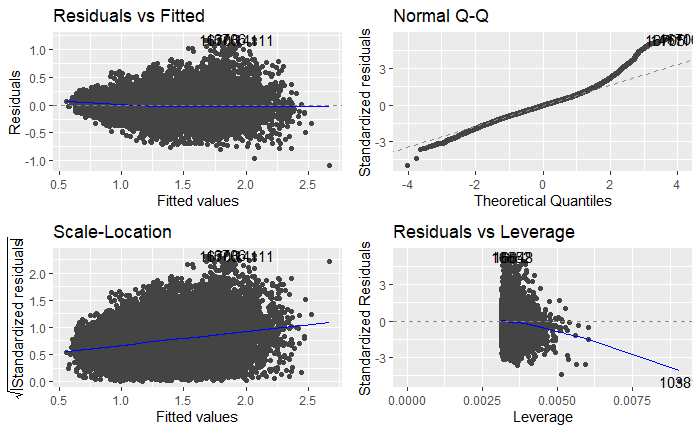

The plots here follow a very similar trend as seen previously above, and are considered “acceptable” for this model.

K-fold validation

Using k-fold validation to check if the model is appropriate over various validation datasets.

```r
cv_10_fold <- trainControl(method = "cv",
                           number = 10,
                           savePredictions = TRUE)

model_kfold_val <- train(average_price ~ type + prop_4225 + year + prop_large_bags +
              ln_total_volume + prop_4046 + region,
               avocado_clean,
               trControl = cv_10_fold,
               method = "lm")

summary(model_kfold_val)
```

```
Call:
lm(formula = .outcome ~ ., data = dat)

Residuals:
     Min       1Q   Median       3Q      Max
-1.08017 -0.13602 -0.00544  0.11696  1.19596

Coefficients:
                           Estimate Std. Error t value Pr(>|t|)
(Intercept)                4.111065   0.047052  87.373  < 2e-16 ***
typeorganic               -0.457570   0.015433 -29.649  < 2e-16 ***
prop_4225                  0.426345   0.010924  39.027  < 2e-16 ***
year2016                   0.095773   0.004509  21.241  < 2e-16 ***
year2017                   0.336374   0.004830  69.636  < 2e-16 ***
year2018                   0.254660   0.007595  33.530  < 2e-16 ***
prop_large_bags           -0.064779   0.007768  -8.339  < 2e-16 ***
ln_total_volume           -0.282391   0.004014 -70.347  < 2e-16 ***
prop_4046                  0.346972   0.013873  25.011  < 2e-16 ***
regionAtlanta              0.244365   0.018658  13.097  < 2e-16 ***
regionBaltimoreWashington  0.564458   0.019200  29.399  < 2e-16 ***
regionBoise               -0.179356   0.017333 -10.348  < 2e-16 ***
regionBoston               0.478720   0.018291  26.173  < 2e-16 ***
regionBuffaloRochester     0.201805   0.017097  11.803  < 2e-16 ***
regionCalifornia           0.964446   0.024236  39.793  < 2e-16 ***
regionCharlotte            0.316913   0.017344  18.272  < 2e-16 ***
regionChicago              0.545683   0.019932  27.377  < 2e-16 ***
regionCincinnatiDayton     0.087674   0.018045   4.859 1.19e-06 ***
regionColumbus            -0.038116   0.017505  -2.177 0.029460 *
regionDallasFtWorth        0.198140   0.020131   9.842  < 2e-16 ***
regionDenver               0.389222   0.019559  19.900  < 2e-16 ***
regionDetroit              0.210085   0.018121  11.593  < 2e-16 ***
regionGrandRapids          0.024755   0.016966   1.459 0.144568
regionGreatLakes           0.848715   0.022637  37.493  < 2e-16 ***
regionHarrisburgScranton   0.315683   0.017469  18.071  < 2e-16 ***
regionHartfordSpringfield  0.530962   0.017803  29.825  < 2e-16 ***
regionHouston              0.168192   0.020127   8.357  < 2e-16 ***
regionIndianapolis        -0.032838   0.017167  -1.913 0.055784 .
regionJacksonville         0.109528   0.017982   6.091 1.15e-09 ***
regionLasVegas             0.178873   0.018006   9.934  < 2e-16 ***
regionLosAngeles           0.639076   0.022298  28.661  < 2e-16 ***
```

[output cut: 22 more lines]

```
regionSouthCentral         0.681232   0.023722  28.717  < 2e-16 ***
regionSoutheast            0.835615   0.021989  38.001  < 2e-16 ***
regionSpokane             -0.056673   0.017299  -3.276 0.001054 **
regionStLouis              0.151505   0.017738   8.541  < 2e-16 ***
regionSyracuse            -0.015503   0.016945  -0.915 0.360275
regionTampa                0.187368   0.017917  10.458  < 2e-16 ***
regionTotalUS              1.448321   0.029284  49.458  < 2e-16 ***
regionWest                 0.977341   0.024247  40.308  < 2e-16 ***
regionWestTexNewMexico     0.274789   0.019183  14.325  < 2e-16 ***
---
Signif. codes:  0 ‘***’ 0.001 ‘**’ 0.01 ‘*’ 0.05 ‘.’ 0.1 ‘ ’ 1

Residual standard error: 0.2189 on 18172 degrees of freedom
Multiple R-squared:  0.705, Adjusted R-squared:  0.704
F-statistic:   712 on 61 and 18172 DF,  p-value: < 2.2e-16
```

| RMSE | Rsquared | MAE | Resample |
| --- | --- | --- | --- |
| 0.2138635 | 0.7158104 | 0.1604400 | Fold01 |
| 0.2133372 | 0.7076986 | 0.1599417 | Fold02 |
| 0.2210526 | 0.7027895 | 0.1649782 | Fold03 |
| 0.2159282 | 0.6998894 | 0.1617106 | Fold04 |
| 0.2153062 | 0.7212128 | 0.1611707 | Fold05 |
| 0.2248532 | 0.7009050 | 0.1657580 | Fold06 |
| 0.2240419 | 0.6895246 | 0.1688578 | Fold07 |
| 0.2213452 | 0.6980894 | 0.1681985 | Fold08 |
| 0.2155769 | 0.7063774 | 0.1635048 | Fold09 |
| 0.2271771 | 0.6917359 | 0.1675237 | Fold10 |

The model shows that rsquared value ranges from ~0.69 to 0.72 across the 10 different validation sets which shows that the model itself should be well-suited for predicting average avocado prices for any new data it sees as the current model yields consistent results with the current data.

Time to test the model against the test data set.

| average_price | pred | resid |
| --- | --- | --- |
| 1.40 | 1.4011600 | -0.0011600282 |
| 1.45 | 1.4629030 | -0.0129030049 |
| 1.21 | 1.5415997 | -0.3315997206 |
| 1.85 | 1.8327430 | 0.0172569897 |
| 1.13 | 1.4725878 | -0.3425877789 |
| 1.32 | 1.2589768 | 0.0610231663 |
| 1.74 | 1.7370486 | 0.0029514370 |
| 1.36 | 1.1676300 | 0.1923699944 |
| 1.95 | 1.7366534 | 0.2133466237 |
| 1.62 | 1.6486535 | -0.0286534605 |

[output cut: 990 more lines]